# DSF 17.02.2016 regression report

Moskvichev Arseny

Wednesday, February 17, 2016

gender and interaction with gender

Predicted variables:

WHOsum (World health organisation well-being index (sum of all scales)) PCPTSD

# Section 1. Predicting PCPTSD score

First, let’s visualize the PCPTSD score distribution:

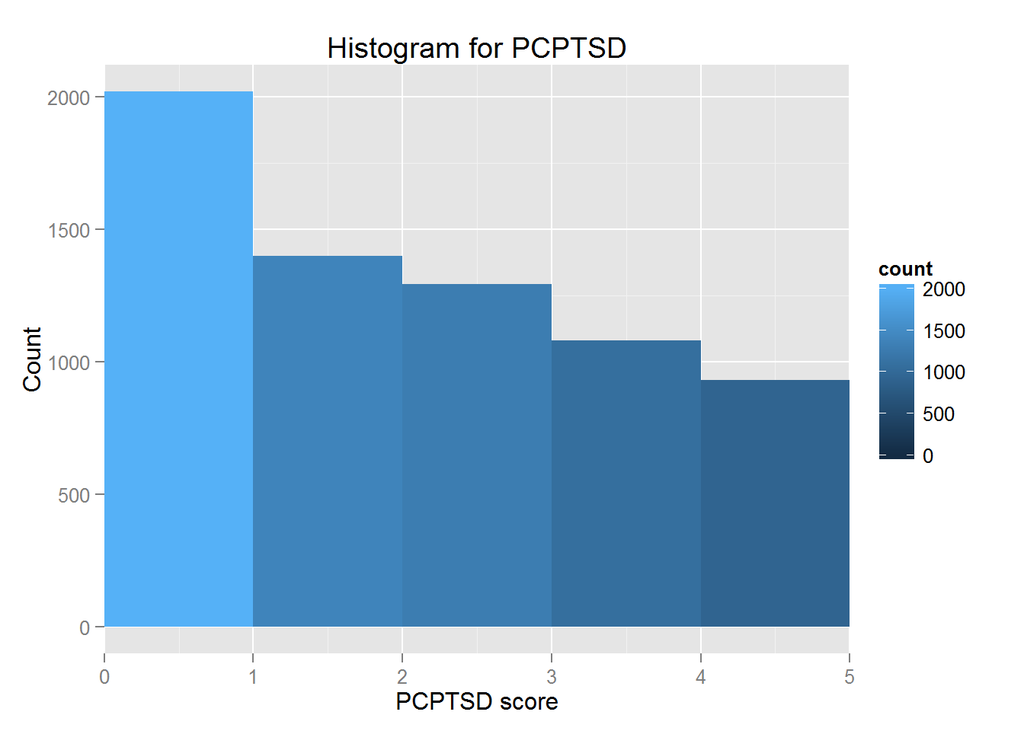

The histogram shape strongly suggests non-normal distribution of the variable under consideration. Moreover, no strong theoretical or other evidence support the idea that we should treat the distances between different test scores to be equal.

So unfortunately, the usage of the ordinary least squares linear regression would be a very doubtful choice, since this model assumes continous dependent variable.

We can perform ordinal logistic regression later (if necessary). (там вроде бы ничего интересного?)

# Section 2. Predicting WHO score

Based on our theoretical views and previous investigations, we selected the following variables as predictors in our linear model:

- Physical assault from stranger
- Physical assault from an acquaintance
- Sexual harassment
- Gender

We also expected interaction between gender and other predictors

Here is the summary of our basic linear model without interaction:

```
##
## Call:
## lm(formula = WHOsum ~ ., data = WHO_prediction_data)
##
## Residuals:
##     Min      1Q  Median      3Q     Max
## -64.437 -12.088   3.563  14.411  48.103
##
## Coefficients:
##             Estimate Std. Error t value Pr(>|t|)
## (Intercept)  72.9667     1.2802  56.994  < 2e-16 ***
## gender       -1.7776     0.5864  -3.032  0.00244 **
## val.15       -2.8674     0.2855 -10.043  < 2e-16 ***
## val.16       -1.4814     0.3640  -4.070 4.75e-05 ***
## val.17       -0.6257     0.3084  -2.029  0.04253 *
## ---
## Signif. codes:  0 '***' 0.001 '**' 0.01 '*' 0.05 '.' 0.1 ' ' 1
##
## Residual standard error: 18.82 on 6719 degrees of freedom
## Multiple R-squared:  0.02807,    Adjusted R-squared:  0.02749
## F-statistic: 48.52 on 4 and 6719 DF,  p-value: < 2.2e-16
```

To estimate the homoscedasticity of residuals, we can plot the residuals for different values of predictors:

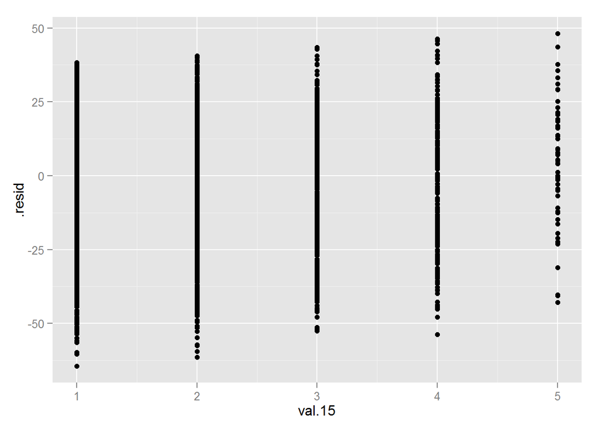

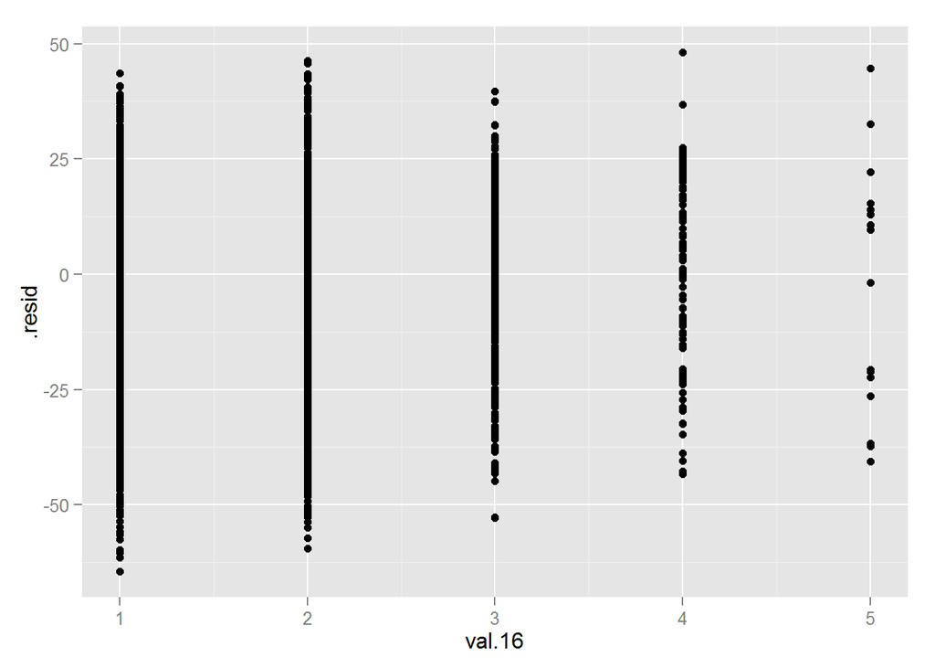

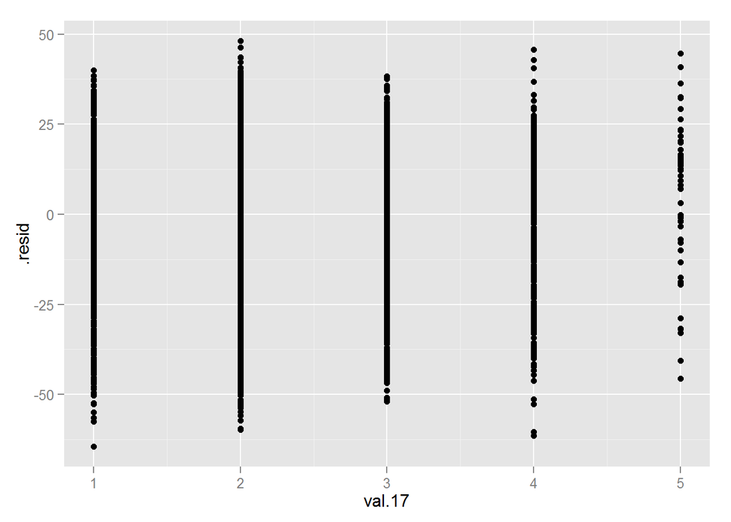

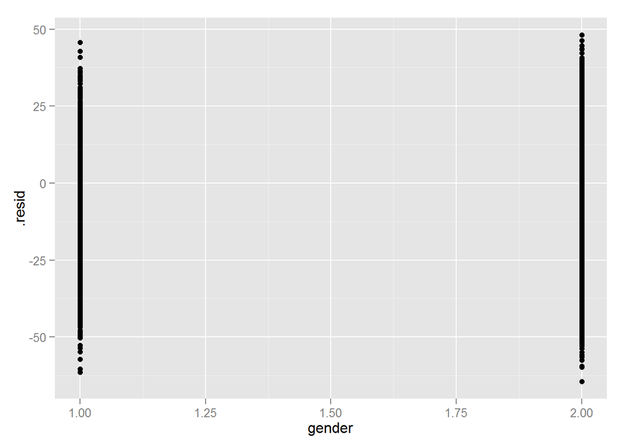

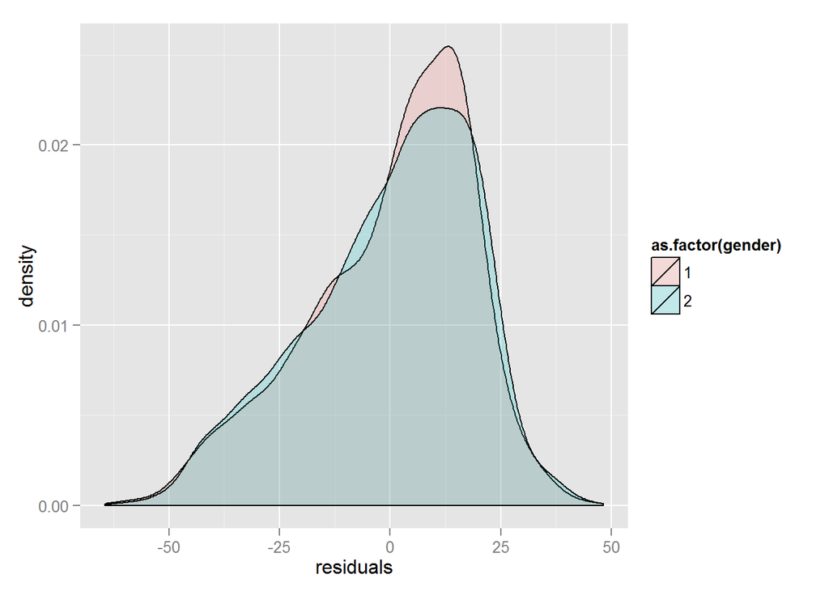

Residuals look heteroscedastic and even non-normal. This may indicate the fact that we need to include interactions, as was suggested in the first place.

Howewer, adding doing so does not mitigate the problem at all.

```
##
## Call:
## lm(formula = WHOsum ~ val.15 + val.16 + val.17 + gender + val.17:gender +
##     val.16:gender, data = WHO_prediction_data)
##
## Residuals:
##     Min      1Q  Median      3Q     Max
## -64.559 -11.852   3.441  14.301  47.306
##
## Coefficients:
##               Estimate Std. Error t value Pr(>|t|)
## (Intercept)    71.9064     3.4043  21.122   <2e-16 ***
## val.15         -2.8605     0.2855 -10.018   <2e-16 ***
## val.16         -4.2253     1.7615  -2.399   0.0165 *
## val.17          1.5447     1.1984   1.289   0.1975
## gender         -1.1705     1.8372  -0.637   0.5241
## val.17:gender  -1.2758     0.6753  -1.889   0.0589 .
## val.16:gender   1.5432     0.9460   1.631   0.1029
## ---
## Signif. codes:  0 '***' 0.001 '**' 0.01 '*' 0.05 '.' 0.1 ' ' 1
##
## Residual standard error: 18.81 on 6717 degrees of freedom
## Multiple R-squared:  0.02881,    Adjusted R-squared:  0.02794
## F-statistic:  33.2 on 6 and 6717 DF,  p-value: < 2.2e-16
```

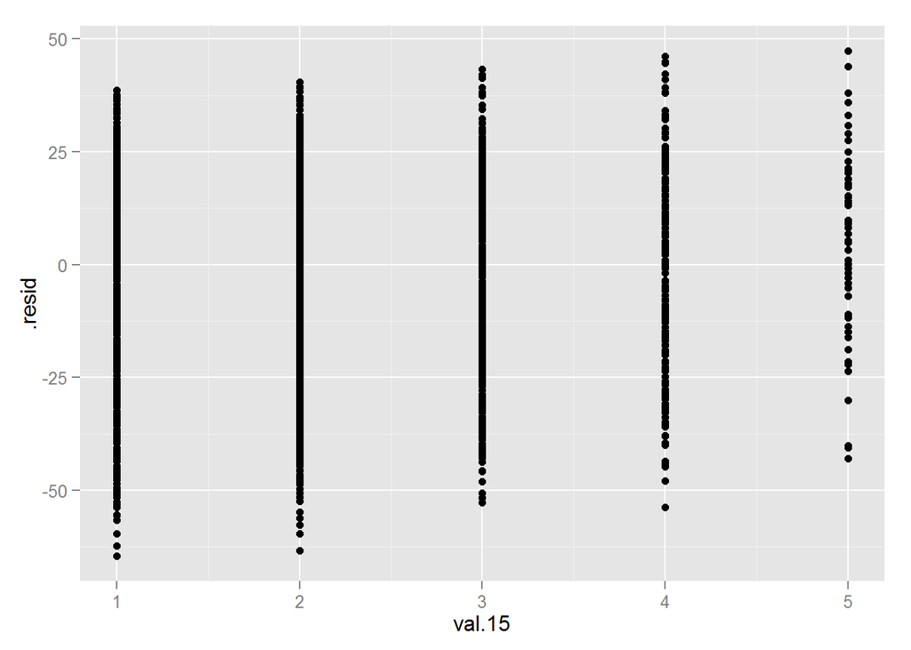

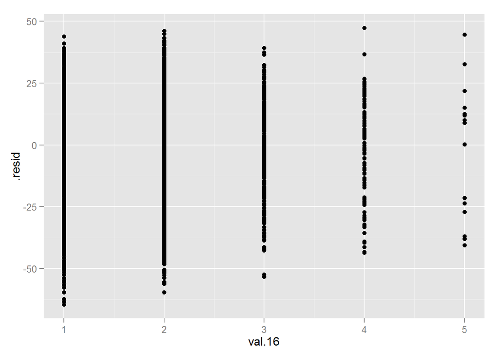

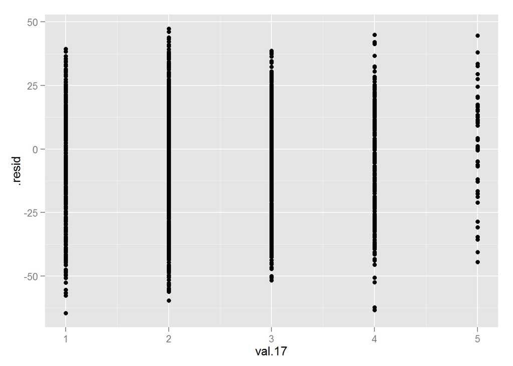

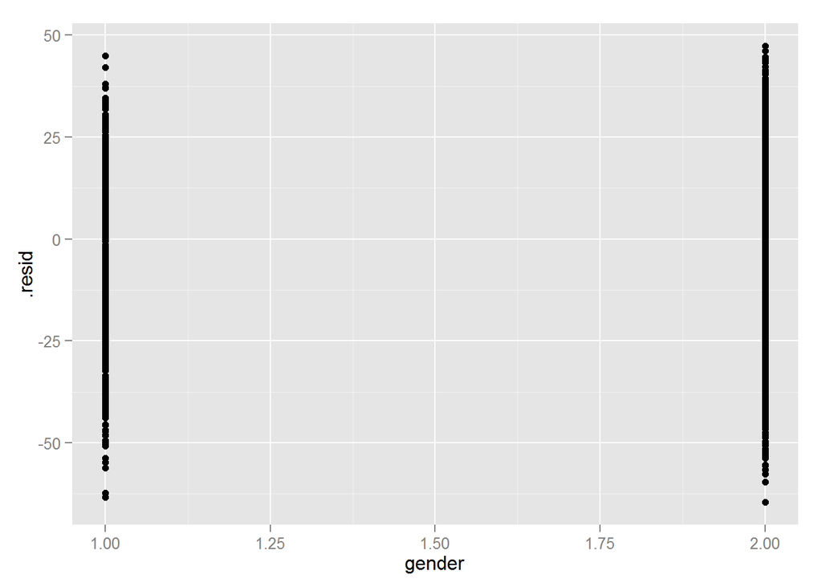

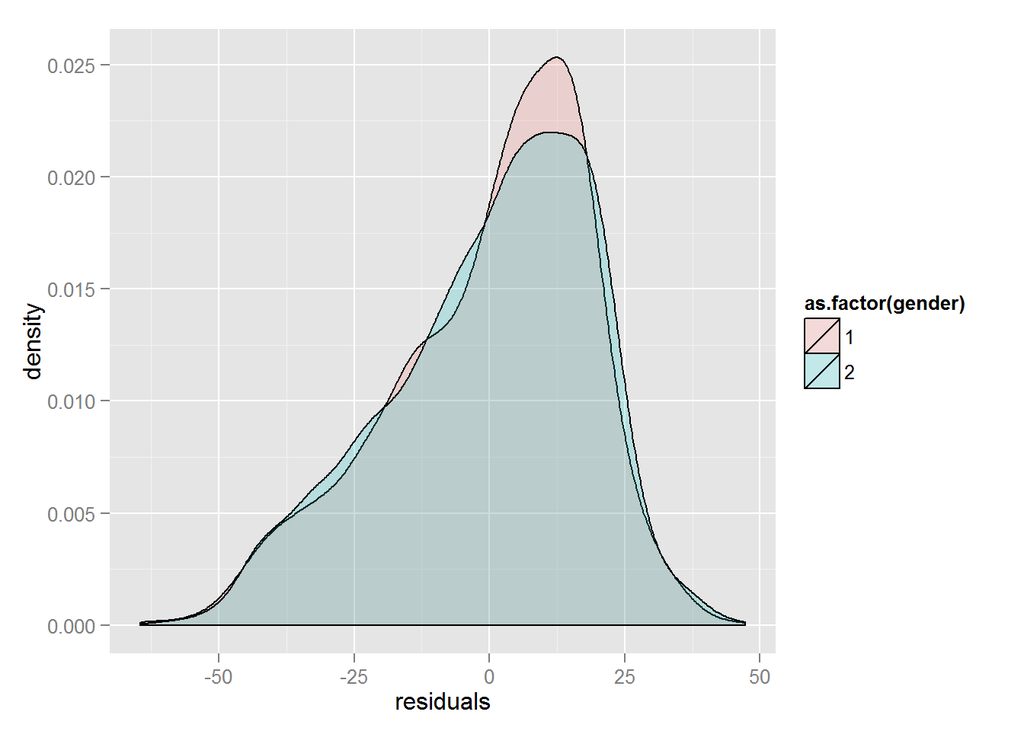

Indeed, the residuals are not distributed normally in general, even in the model that includes interactions:

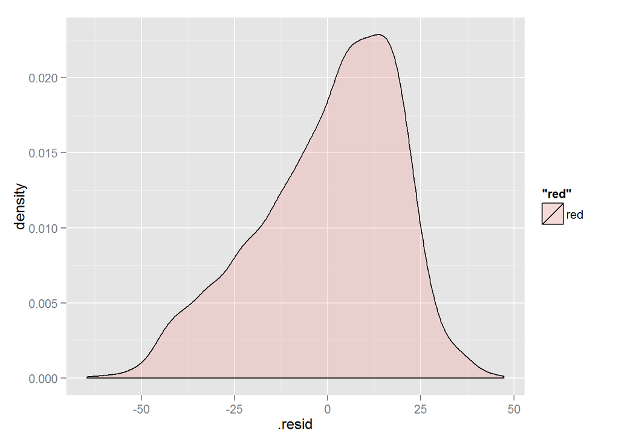

This may only indicate the fact that the suggested simple linear regression model is not suitable for our data. Possible solutions include adding more variables in the model (which ones - should be suggested by literature review), switching to the model with lots of dummy-variables, using ordinal regression, using more predictors and principal component analysis to find the underlying variables, explaining most of the variance, and so on.